# TORNADO Is The Most Deadly Event Whlie FLOOD Is The No.1 Economic Killer

## Data Processing

Load the CSV file into R

```r
setwd("~/Desktop/coursera-rep/assessment2")
mydata<-read.csv("repdata-data-StormData.csv")
names(mydata)<-tolower(names(mydata))
```

To get total number of dealth for each event and arrange them in descending order, then store it in a new variable called “total_fatality_event”. Also get total number of injury for each event and arrange them in descending order, then store it in a new variable called “total_injury_event”

```r
library(dplyr)
```

```r
library(ggplot2)
library(car)
total_fatality_event<-mydata %>%
        group_by(evtype) %>%
        summarize(tf=sum(fatalities)) %>%
        arrange(desc(tf))
total_injury_event<-mydata %>%
        group_by(evtype) %>%
        summarize(ti=sum(injuries)) %>%
        arrange(desc(ti))
```

The property damage expenses will be calculated using two variables in the data set: “propdmg”, and “propexp”. Then same calculation was applied to crop damage expenses. mydata$propdmgexp

```r
#To see which exponent are used for both variables
summary(mydata$propdmgexp)
```

```
##             -      ?      +      0      1      2      3      4      5
## 465934      1      8      5    216     25     13      4      4     28
##      6      7      8      B      h      H      K      m      M
##      4      5      1     40      1      6 424665      7  11330
```

```r
summary(mydata$cropdmgexp)
```

```
##             ?      0      2      B      k      K      m      M
## 618413      7     19      1      9     21 281832      1   1994
```

```r
#To transfer the exponent factor into power values which can be applied to damage variable for calculation, a translator function was at first created and used to loop through the data set. This process took a very long time (~2 hours) although the final result was correct. So I further investigated for other approaches and found a much easier and quicker way and that's by using recode() function in car package.
mydata$propdmgexp<-as.numeric(recode(as.character(mydata$propdmgexp), "''=0; '-'=0; '?'=0; '+'=0; '0'=1; '1'= 10; '2'=10^2; '3'=10^3; '4'=10^4; '5'=10^5; '6'=10^6; '7'=10^7; '8'=10^8; 'B'=10^9; 'h'=100; 'H'=100; 'K'=1000; 'm'=10^6; 'M'=10^6"))
mydata$cropdmgexp<-as.numeric(recode(as.character(mydata$cropdmgexp), "''=0; '?'=0; '0'=1; '2'=10^2; 'B'=10^9; 'k'=1000; 'K'=1000;  'm'=10^6; 'M'=10^6"))
#To calculate the total damage
mydata<-mydata %>% mutate(totaldmg=mydata$propdmgexp*mydata$propdmg+mydata$cropdmgexp*mydata$cropdmg)
total_dmg_event<-mydata %>%
        group_by(evtype) %>%
        summarize(td=sum(totaldmg)) %>%
        arrange(desc(td))
```

## Results

-Question1: Across the United States, which types of events (as indicated in the EVTYPE variable) are most harmful with respect to population health?

By using ggplot2, we present a bar plot of top 5 events causing Deaths and injury.

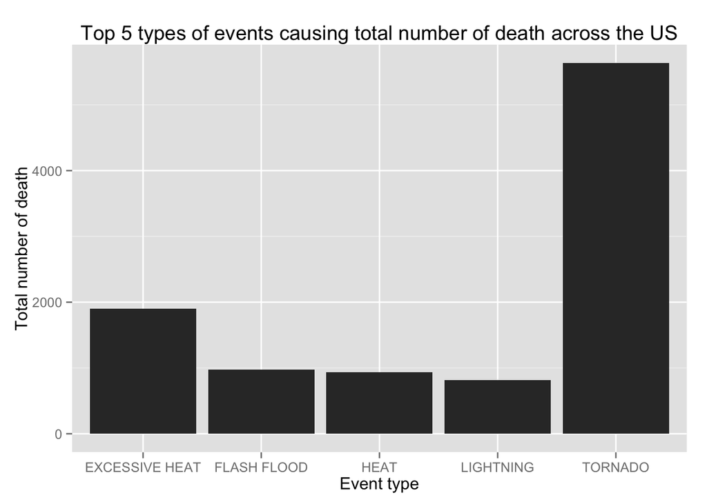

```r
ggplot(total_fatality_event[1:5,], aes(evtype, tf)) + geom_bar(stat = "identity") + labs (title = "Top 5 types of events causing total number of death across the US") + labs (x = "Event type", y ="Total number of death")
```

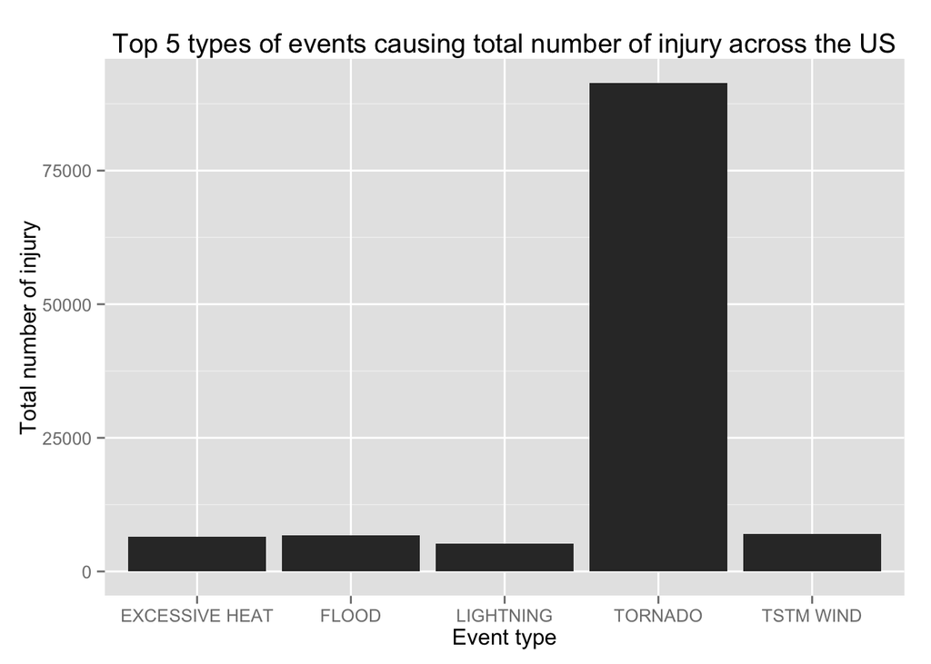

```r
ggplot(total_injury_event[1:5,], aes(evtype, ti)) + geom_bar(stat = "identity") + labs (title = "Top 5 types of events causing total number of injury across the US") + labs (x = "Event type", y ="Total number of injury")
```

-Quenstion 2: Across the United States, which types of events have the greatest economic consequences?

By using ggplot2, we present a bar plot of top 5 events causing economic damages.

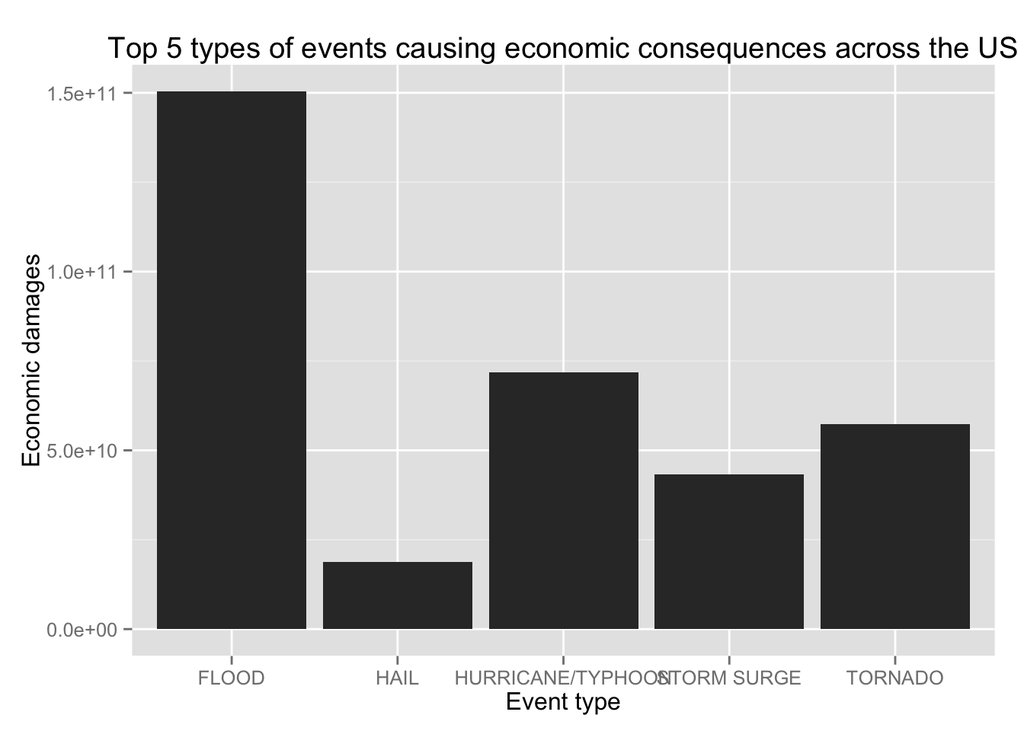

```r
ggplot(total_dmg_event[1:5,], aes(evtype, td)) + geom_bar(stat = "identity") + labs (title = "Top 5 types of events causing economic consequences across the US") + labs (x = "Event type", y ="Economic damages")
```